# 06-exercises

Anurag Lal

2016-05-22

## Reading:

- **APM** Chapter 8.6 and 8.8
- **APM** Chapter 14.8
- **APM** Chapter 7.1 & 7.3 “Non-Linear Regression Models”
- **APM** Chapter 13.2 & 13.4 “Non-Linear Classifcation Models”

## Fuel Economy

Start by making choosing a metric and making a naive guess of model performance:

Show your work below for the calculations

```r
rmse <- function(y,yhat) {
  ( y - yhat )^2  %>% mean   %>% sqrt
}

naive_guess = mean(cars2010$FE)

err_naive_guess = rmse(cars2010$FE,naive_guess)
err_naive_guess
```

```
## [1] 7.494645
```

Based only your intuition, how low do your think you can get your metric: **difference between predicted and actual outcome**_______

## Examine your data

- Plot your response/outcome
- Make a guess of a strong predictor: ______EngDispl___________
- Plot your response vs your predictor.

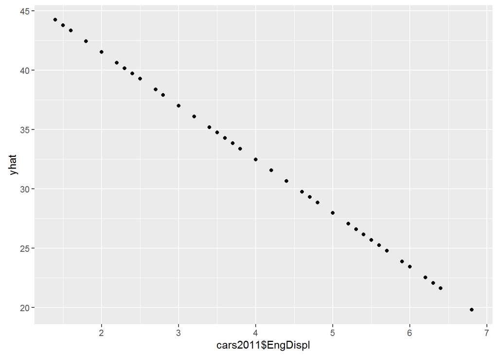

```r
fit.lm.init<-lm(FE ~ EngDispl,data=cars2010)

yhat <- predict(fit.lm.init,cars2011)
qplot(cars2011$EngDispl,yhat)
```

## Build Simple Models

Using **caret**, build a simple linear model and a simple tree model.

```r
library(caret)

ctrl<-trainControl(method="boot",savePredictions = T)
fit.lm <- train(FE ~ EngDispl,data=cars2011,trControl=ctrl,method="glm")
fit.rp <- train(FE ~ EngDispl,data=cars2011,trControl=ctrl,method="rpart")
```

What did you learn about the data from these models.

## Build More Advanced Models

Now refine your models. Use **caret** to build advanced models: - one that uses model averaging (bagging) - one that uses boosting

```r
# Your work here.
fit.bag   <- train(FE ~ EngDispl,data=cars2011,trControl=ctrl,method="bagEarth")

fit.boost <- train(FE ~ EngDispl,data=cars2011,trControl=ctrl,method="gbm",verbose=F)
```

## Conclusion

Which model would you use and why? Under different circumstances why would you choose one of the other models.